# Open Source Bayesian Inference in Python with PyMC3

## FOSSCON • Philadelphia • August 26, 2017

## [@AustinRochford](https://twitter.com/AustinRochford)

## Who am I?

[figure not shown]

### [@AustinRochford](https://twitter.com/AustinRochford) • [GitHub](https://github.com/AustinRochford/) • Website

### austin.rochford@gmail.com • arochford@monetate.com

### PyMC3 developer • Principal Data Scientist at [Monetate Labs](http://www.monetate.com/)

## Bayesian Inference

A motivating question:

> A rare disease is present in one out of one hundred thousand people. A test gives the correct diagnosis 99.9% of the time. What is the probability that a person that tests positive has the disease?

### Conditional Probability

[*Conditional probability*](https://en.wikipedia.org/wiki/Conditional_probability) is the probability that one event will happen, given that another event has occured.

$$ \begin{align*} P(A\ |\ B) & = \textrm{the probability that } A \textrm{ will happen if we know that } B \textrm{ has happened} \\ & = \frac{P(A \textrm{ and } B)}{P(B)}. \end{align*} $$

Our question,

> A rare disease is present in one out of one hundred thousand people. A test gives the correct diagnosis 99.9% of the time. What is the probability that a person that tests positive has the disease?

becomes

$$ \begin{align*} P(+) & = 10^{-5} \\ \\ P(\textrm{Test } +\ |\ +) & = 0.999 \\ P(\textrm{Test } -\ |\ -) & = 0.999 \\ \\ P(+\ |\ \textrm{Test } +) & =\ \textbf{?} \end{align*} $$

### Bayes' Theorem

[Bayes' theorem](https://en.wikipedia.org/wiki/Bayes%27_theorem) shows how to get from $P(B\ |\ A)$ to $P(A\ |\ B)$.

[figure not shown]

$$ \begin{align*} P(+\ |\ \textrm{Test } +) & = \frac{P(\textrm{Test } +\ |\ +) P(+)}{P(\textrm{Test } +)} \\ & = \frac{P(\textrm{Test } +\ |\ +) P(+)}{P(\textrm{Test } +\ |\ +) P(+) + P(\textrm{Test } +\ |\ -) P(-)} \end{align*} $$

$$ \begin{align*} P(+) & = 10^{-5} \\ P(\textrm{Test } +\ |\ +) & = 0.999 \\ P(\textrm{Test } -\ |\ -) & = 0.999 \\ \\ P(+\ |\ \textrm{Test } +) & = \frac{P(\textrm{Test } +\ |\ +) P(+)}{P(\textrm{Test } +\ |\ +) P(+) + P(\textrm{Test } +\ |\ -) P(-)} \\ & = \frac{0.999 \times 10^{-5}}{0.999 \times 10^{-5} + 0.001 \times \left(1 - 10^{-5}\right)} \end{align*} $$

```python
0.999 * 1e-5 / (0.999 * 1e-5 + 0.001 * (1 - 1e-5))
```

```
0.009891284975940117
```

## Probabilistic Programming for Bayesian Inference

[figure not shown]

We know the disease is present in one in one hundred thousand people.

```python
import pymc3 as pm

with pm.Model() as disease_model:
    has_disease = pm.Bernoulli('has_disease', 1e-5)
```

If a person has the disease, there is a 99.9% chance they test positive. If they do not have the disease, there is a 0.1% chance they test positive.

```python
with disease_model:
    p_test_pos = has_disease * 0.999 + (1 - has_disease) * 0.001
```

This person has tested positive for the disease.

```python
with disease_model:
    test_pos = pm.Bernoulli('test_pos', p_test_pos, observed=1)
```

What is the probability that this person has the disease?

```python
with disease_model:
    disease_trace = pm.sample(draws=10000, random_seed=SEED)
```

```
Assigned BinaryGibbsMetropolis to has_disease
```

```python
disease_trace['has_disease']
```

```
array([0, 0, 0, ..., 0, 0, 0])
```

```python
disease_trace['has_disease'].mean()
```

```
0.0104
```

```python
0.999 * 1e-5 / (0.999 * 1e-5 + 0.001 * (1 - 1e-5))
```

```
0.009891284975940117
```

### Monte Carlo Methods

```python
N = 5000

x, y = np.random.uniform(0, 1, size=(2, N))
```

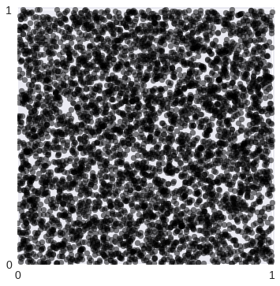

```python
fig
```

```python
in_circle = x**2 + y**2 <= 1
```

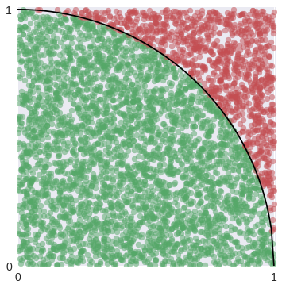

```python
fig
```

```python
4 * in_circle.mean()
```

```
3.1272000000000002
```

#### History of Monte Carlo Methods

[figure not shown]

## The Monty Hall Problem

[figure not shown]

Initially, we have no information about which door the prize is behind.

```python
with pm.Model() as monty_model:
    prize = pm.DiscreteUniform('prize', 0, 2)
```

If we choose door one:

[output not shown]

```python
from theano import tensor as tt

with monty_model:
    p_open = pm.Deterministic('p_open',
                              tt.switch(tt.eq(prize, 0),
                                        # it is behind the first door
                                        np.array([0., 0.5, 0.5]),
                              tt.switch(tt.eq(prize, 1),
                                        # it is behind the second door
                                        np.array([0., 0., 1.]),
                                        # it is behind the third door
                                        np.array([0., 1., 0.]))))
```

Monty opened the third door, revealing a goat.

[figure not shown]

```python
with monty_model:
    opened = pm.Categorical('opened', p_open, observed=2)
```

Should we switch our choice of door?

```python
with monty_model:
    monty_trace = pm.sample(draws=10000, random_seed=SEED)

monty_df = pm.trace_to_dataframe(monty_trace)
```

```
Assigned Metropolis to prize
```

```python
monty_df.prize.head()
```

```
0    0
1    0
2    0
3    0
4    1
Name: prize, dtype: int64
```

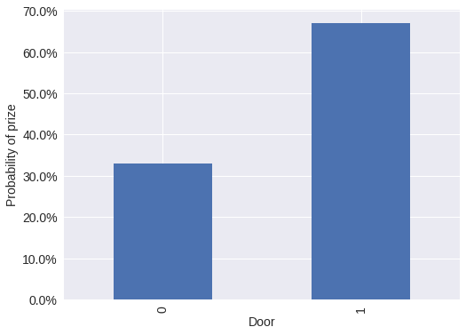

```python
fig
```

Yes, we should switch our choice of door.

## Introduction to PyMC3

From the [PyMC3 documentation](http://pymc-devs.github.io/pymc3/):

> PyMC3 is a Python package for Bayesian statistical modeling and Probabilistic Machine Learning which focuses on advanced Markov chain Monte Carlo and variational fitting algorithms. Its flexibility and extensibility make it applicable to a large suite of problems.

[figure not shown]

As of October 2016, PyMC3 is a [NumFOCUS fiscally sponsored project](https://www.numfocus.org/blog/numfocus-announces-new-fiscally-sponsored-project-pymc3/).

### Features

- Uses [Theano](http://deeplearning.net/software/theano/) as a computational backend
  - Automated differentiation, dynamic C compilation, GPU integration
- Implements Hamiltonian Monte Carlo and [No-U-Turn sampling](https://arxiv.org/abs/1111.4246)
- High-level GLM (`R`-like syntax) and Gaussian process specification
- General framework for [variational inference](https://en.wikipedia.org/wiki/Variational_Bayesian_methods)

### Contributing

[figure not shown]

[Discourse](https://discourse.pymc.io/)

[figure not shown]

## Case Study: Sleep Deprivation

[figure not shown]

```python
sleep_df.head()
```

|  | reaction | days | subject | reaction_std |
| --- | --- | --- | --- | --- |
| 0 | 249.5600 | 0 | 308 | -0.868968 |
| 1 | 258.7047 | 1 | 308 | -0.706623 |
| 2 | 250.8006 | 2 | 308 | -0.846944 |
| 3 | 321.4398 | 3 | 308 | 0.407108 |
| 4 | 356.8519 | 4 | 308 | 1.035777 |

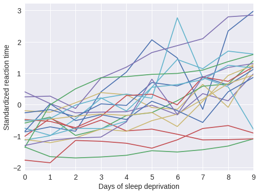

```python
fig
```

Each subject has a baseline reaction time, which should not be too far apart.

```python
with pm.Model() as sleep_model:
    μ_α = pm.Normal('μ_α', 0., 5.)
    σ_α = pm.HalfCauchy('σ_α', 5.)
    α = pm.Normal('α', μ_α, σ_α, shape=n_subjects)
```

Each subject's reaction time increases at a different rate after days of sleep deprivation.

```python
with sleep_model:
    μ_β = pm.Normal('μ_β', 0., 5.)
    σ_β = pm.HalfCauchy('σ_β', 5.)
    β = pm.Normal('β', μ_β, σ_β, shape=n_subjects)
```

The baseline reaction time and rate of increase lead to the observed reaction times.

```python
with sleep_model:
    μ = pm.Deterministic('μ', α[subject_ix] + β[subject_ix] * days)
    σ = pm.HalfCauchy('σ', 5.)
    obs = pm.Normal('obs', μ, σ, observed=reaction_std)
```

```python
N_JOBS = 3
JOB_SEEDS = [SEED + i for i in range(N_JOBS)]

with sleep_model:
    sleep_trace = pm.sample(njobs=N_JOBS, random_seed=JOB_SEEDS)
```

```
Auto-assigning NUTS sampler...
Initializing NUTS using jitter+adapt_diag...
```

### Convergence Diagnostics

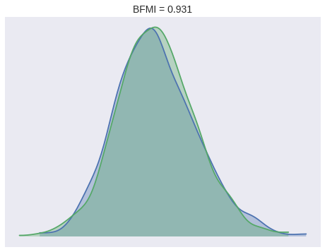

```python
ax = pm.energyplot(sleep_trace, legend=False)
ax.set_title("BFMI = {:.3f}".format(pm.bfmi(sleep_trace)));
```

```python
max(np.max(gr_values) for gr_values in pm.gelman_rubin(sleep_trace).values())
```

```
1.0019478091296214
```

### Prediction

```python
with sleep_model:
    pp_sleep_trace = pm.sample_ppc(sleep_trace)
```

```python
pp_df.head()
```

|  | reaction | days | subject | reaction_std | pp_0 | pp_1 | pp_10 | pp_100 | pp_101 | pp_102 | ... | pp_90 | pp_91 | pp_92 | pp_93 | pp_94 | pp_95 | pp_96 | pp_97 | pp_98 | pp_99 |
| --- | --- | --- | --- | --- | --- | --- | --- | --- | --- | --- | --- | --- | --- | --- | --- | --- | --- | --- | --- | --- | --- |
| 0 | 249.5600 | 0 | 308 | -0.868968 | -0.221133 | -1.094005 | -1.479840 | -0.797150 | -0.251219 | -1.846100 | ... | -0.680005 | -0.036840 | -0.618054 | 0.158745 | -0.986407 | -0.788178 | -1.483328 | -0.423254 | -0.946230 | -0.838087 |
| 1 | 258.7047 | 1 | 308 | -0.706623 | 0.354375 | -1.192640 | -0.424441 | 0.064195 | -0.661047 | -1.181403 | ... | -0.472364 | -0.825356 | -0.374235 | -0.336909 | -0.940759 | -1.236048 | -0.749208 | -0.892589 | 0.243243 | -0.891522 |
| 2 | 250.8006 | 2 | 308 | -0.846944 | 0.487935 | -0.570185 | 0.304536 | 0.758313 | 0.566803 | 0.211791 | ... | -0.512914 | 0.156596 | -0.451047 | -0.219734 | -0.773714 | -0.237561 | -0.199602 | -0.071147 | 0.146439 | -0.193735 |
| 3 | 321.4398 | 3 | 308 | 0.407108 | 0.950116 | -0.554748 | 0.544648 | 1.037173 | -0.245327 | 0.450455 | ... | -0.183340 | 0.289252 | 0.358078 | 1.579609 | 0.652802 | -0.286667 | -0.327654 | 0.607906 | -0.087981 | -0.097427 |
| 4 | 356.8519 | 4 | 308 | 1.035777 | 0.485269 | 0.549079 | 0.564043 | 0.045464 | 0.643697 | 0.190714 | ... | 0.976137 | 0.306833 | 0.744076 | 0.493216 | 0.516644 | 1.090693 | 0.583320 | 1.079374 | 0.996899 | 0.671175 |

5 rows × 504 columns

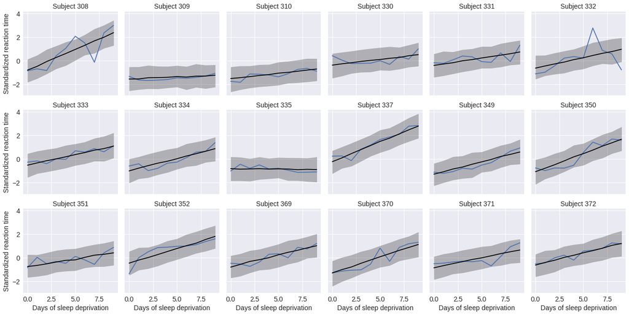

```python
grid.fig
```

## Hamiltonian Monte Carlo in PyMC3

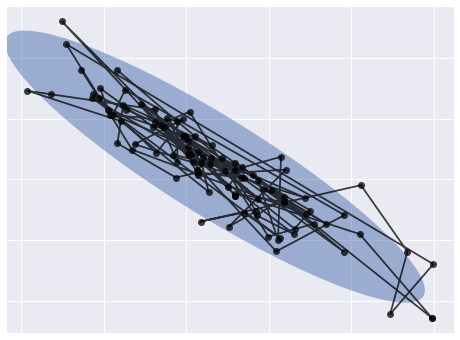

```python
mcmc_fig
```

### The Curse of Dimensionality

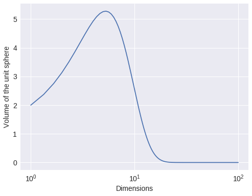

```python
fig
```